# Supplementary Code (explained). Movement-driven modeling reveals new patterns in disease transmission networks

## Introduction

In this document, we present the workflow for reproducing the analysis. The following code can be used to obtain the results shown in the main document starting from any telemetry data, enabling the reproduction of the analysis for other species, diseases, and ecosystems with a few modifications. To minimize changes in the code, we recommend organizing the starting telemetry data for each study area with one row per GPS location and with the following columns:

- ID: Individual identifier
- SP: Species
- lat: Location latitude (WGS 84)
- long: Location longitude (WGS 84)
- TIME: Location time of the day
- DATE: Location date

However, other data structures can also be used if modifying the code.

Note that we carried out the analysis for two study areas: Doñana National Park (DNP) and Sierra de San Pedro (SSP). Although the workflow is designed for one study area, results for both study areas are presented, with repeated code hidden for better understanding.

## 1. Data preparation

We considered different survival rates of the pathogen in the environmentfor each season in the DNP system. Therefore, we divided each individual data per season. In our case, the locations are taken at a constant time interval, making them a valid input for moveSTIR. In the event that our data does not have a constant time interval, either due to configuration or operational errors, the use of the CTMM package (Calabrese *et al.* 2016) may be useful to adjust them to a constant interval (see Calabrese *et al.* 2016; Wilber *et al.* 2022). CTMM also allows for resampling trajectories at a shorter time interval than used in location recording (see Yang *et al.* 2023), although we did not use it in this case to avoid biases derived from inferring the trajectory between two locations.

MoveSTIR models each pair of individuals separately, so we need to generate a `.csv` document with the GPS data of each individual.

**Required changes:**

- Line 5: telemetry data to load.
- Line 11: Date and time format.
- Line 12: Time zone
- Lines 18-35: Skip if the analysis is not by season.
- Line 37: Output name.
- Line 46: Directory for storing the trajectories.

```r
# Requried package
library(data.table)

# Loading trajectory data (already pre-processed, i.e. checking for outliers, etc.)
dat <- data.table(read.csv("gps_dnp.csv", sep = ";", header = T,
                           encoding = "UTF-8"))

# Date and time together as a date time formatted field
dat$date_time <- as.POSIXct(strptime(paste(dat$DATE, sub('^(\\d+:\\d+)$', '\\1:00',
                                                         dat$TIME), sep = " "),
                                     format = "%d/%m/%Y %H:%M:%S",
                                     tz="Europe/Madrid"))

# Duplicated records should be deleted
setkey(dat, ID, date_time)
dat <- dat[!duplicated(dat, by=key(dat))]
knitr::kable(head(dat), caption = "Table SC1. Data head")
```

| ID | SP | lat | long | TIME | SP.1 | DATE | date_time |
| --- | --- | --- | --- | --- | --- | --- | --- |
| 1 | Red deer | 39.22171 | -6.515602 | 0:10:06 | Red deer | 23/09/2017 | 2017-09-23 00:10:06 |
| 1 | Red deer | 39.22165 | -6.515541 | 0:21:41 | Red deer | 23/09/2017 | 2017-09-23 00:21:41 |
| 1 | Red deer | 39.22170 | -6.515541 | 0:32:27 | Red deer | 23/09/2017 | 2017-09-23 00:32:27 |
| 1 | Red deer | 39.22168 | -6.515511 | 0:44:00 | Red deer | 23/09/2017 | 2017-09-23 00:44:00 |
| 1 | Red deer | 39.22185 | -6.515465 | 0:54:30 | Red deer | 23/09/2017 | 2017-09-23 00:54:30 |
| 1 | Red deer | 39.22165 | -6.515572 | 1:06:01 | Red deer | 23/09/2017 | 2017-09-23 01:06:01 |

```r
# If considering different survival rates of the pathogen in the environment in
# different seasons, each record should include the season for the posterior
# Python code
get_season <- function(dates) {
  WS = as.Date("2000-1-1", format = "%Y-%m-%d") # Winter Solstice
  SE = as.Date("2000-4-1",  format = "%Y-%m-%d") # Spring Equinox
  SS = as.Date("2000-7-1",  format = "%Y-%m-%d") # Summer Solstice
  FE = as.Date("2000-10-1",  format = "%Y-%m-%d") # Fall Equinox

  # Convert dates from any year to 2000 dates
  d = as.Date(strftime(dates, format="2000-%m-%d"))

  ifelse (d >= WS & d < SE, "W",
          ifelse (d >= SE & d < SS, "SP",
                  ifelse (d >= SS & d < FE, "SU", "F")))
}
dat$season <- get_season(dat$date_time)
unique(dat$season)
dat$ID <- paste0(dat$ID, "_", dat$season)

# Saving the new formatted data
fwrite(dat, file = "gps_loc_movestir_doñana.csv")

# Split the dataset by individual with the date and time in seconds
for (i in unique(dat$ID)){
  dat. <- dat[dat$ID == i,] %>%
    mutate(time_s = as.numeric(date_time)) %>%
    rename(x = xcoord, y = ycoord, id = ID) %>%
    select(id, x, y, time_s)

    fwrite(dat., paste0("data_2h/", "traj_", i, ".csv"))
}
```

## 2. Temporal decay

MoveSTIR takes into consideration the decay of pathogens in the environment. **It must be estimated for each case.** We calculated the rate of decay of animal TB in both environments (DNP and SSP) based on mean temperatures, which is the most influential factor (Jackson *et al.*, 1995; Fine *et al.*, 2011). We applied exponential regression to the available data from Jackson *et al.* (1995) and Fine *et al.* (2011) and computed values for our study areas. For DNP, we computed one value for each season, while for SSP, we computed one value for the entire montanera period (October to February).

```r
data <- data.frame(Reference = c("Jackson et al. 1995", "Jackson et al. 1995",
                                 "Jackson et al. 1995", "Fine et al. 2011",
                                 "Fine et al. 2011", "Fine et al. 2011"),
                   Temp = c(18.1, 8.3, 17.7, 0.4, 2.8, 21.8),
                   Days = c(4, 21, 11, 29.88, 29.06, 6.88))
decay <- data.frame(Area = c("DNP (Summer)", "DNP (Fall)", "DNP (Winter)",
                             "DNP (Spring)", "SSP (Montanera)"),
                    Temp = c(24.74, 15.66, 11.85, 19.04, 12.56))
knitr::kable(data, caption = "Table SC2. TB pathogen decay studies") %>%
  kableExtra::kable_styling(full_width = F)
```

Table SC2. TB pathogen decay studies

| Reference | Temp | Days |
| --- | --- | --- |
| Jackson et al. 1995 | 18.1 | 4.00 |
| Jackson et al. 1995 | 8.3 | 21.00 |
| Jackson et al. 1995 | 17.7 | 11.00 |
| Fine et al. 2011 | 0.4 | 29.88 |
| Fine et al. 2011 | 2.8 | 29.06 |
| Fine et al. 2011 | 21.8 | 6.88 |

```r
m_decay <- lm(log(Days) ~ Temp, data = data)
```

```r
stargazer::stargazer(m_decay, type = "html",
                     title = "Table SC3. Pathogen decay regression model")
```

**Table SC3. Pathogen decay regression model**

|  | *Dependent variable:* |
| --- | --- |
|  | log(Days) |
| Temp | -0.083** |
|  | (0.020) |
| Constant | 3.548*** |
|  | (0.279) |
| Observations | 6 |
| R<sup>2</sup> | 0.816 |
| Adjusted R<sup>2</sup> | 0.770 |
| Residual Std. Error | 0.395 (df = 4) |
| F Statistic | 17.738** (df = 1; 4) |
| *Note:* | p<0.1; p<0.05; p<0.01 |

```r
decay$Days <- round(exp(predict(object = m_decay,
                                newdata = list(Temp = decay$Temp))))
knitr::kable(decay, caption = "Table SC4. TB pathogen decay estimates") %>%
  kableExtra::kable_styling(full_width = F)
```

Table SC4. TB pathogen decay estimates

| Area | Temp | Days |
| --- | --- | --- |
| DNP (Summer) | 24.74 | 4 |
| DNP (Fall) | 15.66 | 9 |
| DNP (Winter) | 11.85 | 13 |
| DNP (Spring) | 19.04 | 7 |
| SSP (Montanera) | 12.56 | 12 |

## 3. Relative risk modeling by MoveSTIR (Python)

MoveSTIR can be loaded as Conda environment in Conda or Anaconda. Here we shown the Python code for our analysis.

**Required changes:**

- Lines 26-33: Disease, location, time_interval and telemetry data directory.
- Line 49: Trajectories directory.
- Line 61: Output directory.
- Lines 80-100: Pathogen survival.

```python
# Required packages
import scipy.stats as stats
import pandas as pd
import numpy as np
import matplotlib.pyplot as plt
import seaborn as sns
import scipy.interpolate as interp
import moveSTIR as stir
import os
import logging
from itertools import permutations
import multiprocessing as mp

logging.basicConfig(filename='timeit_movestir.log', format='%(asctime)s %(message)s',
                    datefmt='%m/%d/%Y %I:%M:%S %p')
logger = logging.getLogger(__name__)
logger.setLevel(logging.INFO)
logger.info("Initializing logger")

# Setting initial paramters:
# - Disease (multiple diseases can be included, adding conditionals further down)
# - Pathogen survival in the environment (further down)
# - Location (for the paths and for pathogen survival further down)
# - Time interval on the trajectories (set on CTMM)

disease = "TB"  # it could be other modifying the code below
location = "doñana"
time_interval = "2h"

# Reading the database
dat = pd.read_csv(
  "C:/Files/IREC/PhD/redes/Datasets_{0}/gps_loc_movestir_{1}.csv".
  format(location,location))

# Converting date and time in an integer form
# The result is in nanoseconds so it's divided by 60*10^9 for obtaining
# minute scale
dat = (dat.assign(datetime=lambda x: pd.to_datetime(x.date_time))
              .assign(unix_time = lambda x: x.datetime.astype(np.int64) / (60 * 10**9)))

# Individuals' (hosts) index
host_keys = np.unique(dat.ID)

# Reading trajectories
# Time is in seconds so it is divided by 60 for obtaining minute scale
all_fitted = {}
for h in host_keys:
            af = pd.read_csv(
              "C:/Files/IREC/PhD/redes/Datasets_{2}/data_{1}/traj_{0}.csv".
              format(h,time_interval,location))
            af = af.assign(time=lambda x: x.time_s / 60)
            af = af[["x", "y", "time"]]
            all_fitted[h] = af

host_keys = list(all_fitted.keys())

# Running moveSTIR for obtaining transmission kernels
host_keys = list(all_fitted.keys())
n = len(host_keys)

path = "C:/Files/IREC/PhD/redes/trans_kernels_{0}/{1}".format(location, time_interval)

count = 1

# moveSTIR works by pairs of hosts, repeating the loop for the inference of the
# kernel for every individual being host 1 (i) and every individual being
# host 2 (j)
for i, h1_nm in enumerate(host_keys):
    for j, h2_nm in enumerate(host_keys):

        if i != j:
            logger.info("{0} of {1}".format(count, n*(n - 1)))
            logger.info("Working on {0} lag {1}".format(h1_nm, h2_nm))
            host1 = all_fitted[h1_nm].copy()
            host2 = all_fitted[h2_nm].copy()

            host1, host2 = stir.align_trajectories(host1, host2)
            nt = len(host1)

            # Here we can modify pathogen survival and distance decay according
            # to location or pathogen
            if disease == 'TB':  # Conditionals must be added here if
                                 # multiple diseases are included
            if location == 'extremadura':
                days_permanence = 12

            elif location == 'doñana':
                if 'SU' in h1_nm:
                    days_permanence = 4
                elif 'F' in h1_nm:
                    days_permanence = 9
                elif 'W' in h1_nm:
                    days_permanence = 13
                elif 'SP' in h1_nm:
                    days_permanence = 7

            if location == 'extremadura':
                distance_decay = 26
            elif location == 'doñana':
                distance_decay = 52

            # Pathogen decay in minute scale
            pathogen_decay = 1 / (24 * 60. * days_permanence)
            dd_type = 'cutoff'

            # Running transmission kernels
            # Transmission kernels are heavy, so we use memory mapping to process
            # them to avoid lack of RAM capacity issues following recommendations
            # on Wilber et al. (2022).
            # For our interest, we save from each transmission (host1 from host2)
            # two csv files:
            # direct_indirect FOI csv:
                # column 1: relative FOI for each step in the temporal window
                # (i.e. time gap between visits by the depositor and the acquirer)
                # relative to their total FOI.
                # column 2: time for each time step
            # total FOI csv:
                # column 1: total FOI for each time step
                # column 2: time for each time step
            # After extracting the info, the kernel is deleted,
            try:

                datapath = os.path.join(path, "K_{0}lag{1}.dat".format(h1_nm, h2_nm))
                deltat, K_1lag2, _ = stir.transmission_kernel(host1, host2,
                pathogen_decay, distance_decay, dd_type=dd_type, max_size=1,
                file_path=datapath)

                Kmat = np.memmap(datapath, dtype=np.float32, mode="r",
                shape=(nt, nt))

                column_1 = np.array([np.sum(np.diagonal(Kmat.T,
                offset=offset)*deltat)
                for offset in np.arange(Kmat.shape[0])])
                  column_2 = host1.time.values*60
                  df = pd.DataFrame({'FOI':column_1, 'time':column_2})
                  df.to_csv(os.path.join(path,
                  "direct_indirect_{0}_from_{1}.csv".format(h1_nm, h2_nm,)),
                  index=False)

                column_1 = (Kmat*deltat).sum(axis=1)
                df = pd.DataFrame({'FOI':column_1, 'time':column_2})
                df.to_csv(os.path.join(path,
                "total_{0}_from_{1}.csv".format(h1_nm, h2_nm,)),index=False)


                del (Kmat)

                try:
                    os.remove(datapath)
                except FileNotFoundError:
                    pass

            except IndexError:
                    print("Error for {0} and {1}. No overlap".format(h1_nm, h2_nm))
```

## 4. $λ$ and $β$ estimations

$λ$ (deposition rate) and $β$ (acquisition rate) refer to the amount of pathogen deposited and acquired by hosts per unit of time. **They must be estimated for each case.** As is often the case with wildlife pathogens, we did not have these estimates, so we estimated $λ$ and $β$ by comparing the excretion and infectious dose of each species, and the percentage of infected animals that spread the pathogen. While this approach provides a relative measure of the transmission risk between species, it does not enable us to determine the actual risk of transmission. We extended the information regarding wild boar to Iberian pigs and the information regarding red deer to fallow deer.

We took the highest excretion dose ($ed$) as reference, and estimated the excretion rates ($λ$) for an individual of the species $i$ as:
$$λ_i =p_i·ed_i/ed_{ref}$$
Being:

- $p_i$ the proportion of infected animals of the $i$ species that seed the pathogen,
- $ed_i$ the pathogen excretion dose of the $i$ species, and
- $ed_{ref}$ the pathogen excretion dose of reference.

For the $β$, we considered the highest proportional value (1) when the infectious dose ($id$) was equal to the excretion dose of reference, and a linear decline in the FOI with the decrease of the infectious dose. Therefore, the acquisition rate ($β$) for an individual of the species $i$ is estimated is:
$$β_i = ed_{ref}/id_i$$
Being:

- $id_i$ the pathogen infectious dose of the i species , and
- $ed_{ref}$ the pathogen excretion dose of reference.

Therefore, we our estimates for $λ$ and $β$ are:

```r
param <- data.frame(Species = c("Wild boar/Iberian Pig", "Cattle",
                                "Red deer/Fallow deer"),
                    Reference = c("Santos et al., 2015; Ballestero et al., 2009",
                                  "Neill et al., 2001; McCorry et al., 2005;
                                  Griffin et al., 2006", "Griffin et al., 2006;
                                  Santos et al., 2015"),
                    "% of shedders" = c(79.5, 70.1, 92.9),
                    "Excretion dose (CFU/ml)" = c(1.82*10^2, 9*10^1, 8.37*10^1),
                    "Infectious dose (CFU/ml)" = c(10^3, 5*10^2, 5*10^2),
                    check.names = FALSE)
param$λ <- round((param$`% of shedders`/100)*param$`Excretion dose (CFU/ml)`/
                   max(param$`Excretion dose (CFU/ml)`), digits = 2)
param$β <- round(max(param$`Excretion dose (CFU/ml)`)/
                   param$`Infectious dose (CFU/ml)`, digits = 2)
knitr::kable(param, caption = "Table SC5. λ and β estimates") %>%
  kableExtra::kable_styling(full_width = FALSE)
```

Table SC5. λ and β estimates

| Species | Reference | % of shedders | Excretion dose (CFU/ml) | Infectious dose (CFU/ml) | λ | β |
| --- | --- | --- | --- | --- | --- | --- |
| Wild boar/Iberian Pig | Santos et al., 2015; Ballestero et al., 2009 | 79.5 | 182.0 | 1000 | 0.80 | 0.18 |
| Cattle | Neill et al., 2001; McCorry et al., 2005; Griffin et al., 2006 | 70.1 | 90.0 | 500 | 0.35 | 0.36 |
| Red deer/Fallow deer | Griffin et al., 2006; Santos et al., 2015 | 92.9 | 83.7 | 500 | 0.43 | 0.36 |

## 5. Loading data

Hereafter the analysis is carried out in a single R script. Firstly, all the trajectories are loaded into the R environment and put together in a single object. As is often the case with wildlife telemetry studies, not all animals were marked during the same period of time. Hence, each pair of individuals overlapped for different amounts of time, so individuals that overlapped for longer periods were more likely to be exposed to each other, resulting in higher FOI estimates. To account for this, we divided the FOI by the amount of time that the monitoring of individuals overlapped.

**Required changes:**

- Lines 16-18: locations and sampling interval.
- Line 23: Telemetry data directory.
- Line 33: MoveSTIR output directory.
- Lines 57-79: λ and β estimates for each species.
- Line 117: Join the dataframes created for each study area and sampling interval.

```r
# Required packages
library(tidyverse)
library(sf)
library(ggplot2)
library(ggridges)
library(ggpubr)
library(lubridate)
library(RColorBrewer)
library(viridis)
library(brms)
library(tidybayes)

# Total FOI Databases ----

# Defining deposition and acquisition rates
location = c("doñana", "extremadura")       # locations
tint = c("2h", "10min")                     # sampling intervals
filetype = "total"                          # direct_indirect or total

# Loop for preparing the databases by location and time
for (m in location){                        # for all locations
  for (n in tint){                          # for all sampling intervals
    dat <- read.csv(paste0("C:/Files/IREC/PhD/redes/Datasets_",m,
                           "/gps_loc_movestir_", m, ".csv"))
    host_keys <- unique(dat$ID)             # host IDs
    assign(paste0("dat_", substr(m, start = 1, stop = 2)), dat)
    foi_list <- list()                      # Empty list

# Loop for loading trajectory files
    for (i in host_keys){                   # Host 1
      for (j in host_keys){                 # Host 2
        try({
          a <- read.csv(paste0("C:/Files/IREC/PhD/redes/trans_kernels_", m,
                               "/",n,"/", filetype,"_",
                               i,"_from_",j,".csv"))   # Name of the csv
          names(a) <- c("kernel", "datetime")          # Exposure, date and time
          a$vart <- 1:nrow(a) - 1                   # time step
          a$host1 <- i                              # Host 1
          a$host2 <- j                              # Host 2
          a$datetime <- as_datetime(a$datetime)     # seconds to date and time
          a$h1_species <- dat[dat$ID == i,]$SP[1]   # Host 1 species
          a$h2_species <- dat[dat$ID == j,]$SP[1]   # Host 2 species
          nlist <- paste0("foi_",i,"_",j)           # Name in the list
          foi_list[[nlist]] <- a                    # Add data frame to the list
        }, silent = TRUE)
      }
    }

    try({
# Compiling all the trajectories in a single dataframe
    foi_contact <- Reduce(rbind, foi_list)

# Variable with both hosts
    foi_contact$hosts <- paste(foi_contact$host1, "_from_", foi_contact$host2)

# Including excretion and acquisition
    foi_contact$lambda <- as.numeric(ifelse(foi_contact$h2_species ==
                                              "Wild boar" |
                                              foi_contact$h2_species == "Pig",
                                            0.8, ifelse(
                                              foi_contact$h2_species == "Cattle",
                                              0.35, ifelse(
                                                foi_contact$h2_species ==
                                                  "Red deer" |
                                                  foi_contact$h2_species ==
                                                  "Fallow deer",
                                                0.43, "ERROR"))))

    foi_contact$beta <- as.numeric(ifelse(foi_contact$h1_species ==
                                            "Wild boar" |
                                            foi_contact$h1_species == "Pig",
                                          0.18, ifelse(
                                            foi_contact$h1_species == "Cattle",
                                            0.36, ifelse(
                                              foi_contact$h1_species ==
                                                "Red deer"|
                                                foi_contact$h1_species ==
                                                "Fallow deer",
                                              0.36, "ERROR"))))

# From kernel to FOI
    foi_contact$foi <- foi_contact$kernel * foi_contact$beta *
      foi_contact$lambda

# Variable with the interacting species
    foi_contact$interaction <- paste0(foi_contact$h1_species, "_from_",
                                      foi_contact$h2_species)

# Summarizing FOI by dyads
    foi_sum_1 <- foi_contact[,c(1, 6:8, 12)] %>%
      group_by(hosts, h1_species, h2_species, interaction) %>%
      summarise(total_kernel = sum(kernel))
    foi_sum_2 <- foi_contact[,c(6:8, 11:12)] %>%
      group_by(hosts, h1_species, h2_species, interaction) %>%
      summarise(total_foi = sum(foi))
    foi_sum_3 <- foi_contact[,c(3, 6:8, 12)] %>%
      group_by(hosts, h1_species, h2_species, interaction) %>%
      summarise(total_time = max(vart))
    foi_total <- merge(foi_sum_1, foi_sum_2) %>% merge(foi_sum_3)
    foi_total$hosts <- gsub('[SUFWSP]', '', foi_total$hosts)
    foi_total <- foi_total %>%
      group_by(hosts, h1_species, h2_species, interaction) %>%
      summarise(across(everything(), list(sum)))
    names(foi_total) <- gsub('_1', '', names(foi_total))

# Accounting for monitoring duration
    foi_total$rel_foi <- (foi_total$total_foi/foi_total$total_time)
    foi_total$rel_kernel <- (foi_total$total_kernel/foi_total$total_time)
    foi_total$loc <- m
    foi_total$tint <- n
    assign(paste0("foi_", substr(m, start = 1, stop = 2), "_",
                  substr(n, start = 1, stop = 2)), foi_total)
    }, silent = TRUE)
  }
}

foi <- do.call("rbind", list(foi_do_2h, foi_ex_10)) # If we have several
                                                    # study areas
```

## 6. Comparing risk among species pairs

We compared the FOI among species pairs in both study areas by means of *brms* (Bürkner, 2018), an R package for Bayesian modeling using the probabilistic programming language Stan (Carpenter *et al.*, 2017).

### 6.1. FOI distribution

Firstly, we explored the data to select a distribution for the modeling. The FOI represents count, so we considered Poisson and Negative Binomial distribution.

```r
family_test <- foi$rel_foi_int

k <- mean(family_test)^2/var(family_test); k # mean/variance

par(mfrow = c(1,3))
hist(rpois(n=999, lambda=mean(family_test)), main="Poisson")
hist(rnbinom(n=999, size=k, mu=mean(family_test)), main="Negative binomial")
hist(family_test, breaks=50, main="FOI")
mtext("Figure SC1. Data distribution", side = 3, line = - 1.5,outer = TRUE)
```

**DNP data distribution**

```
## [1] "Mean/variance= 0.135126854763587"
## [2] "Variance much higher than the mean -> Overdispersion"
```

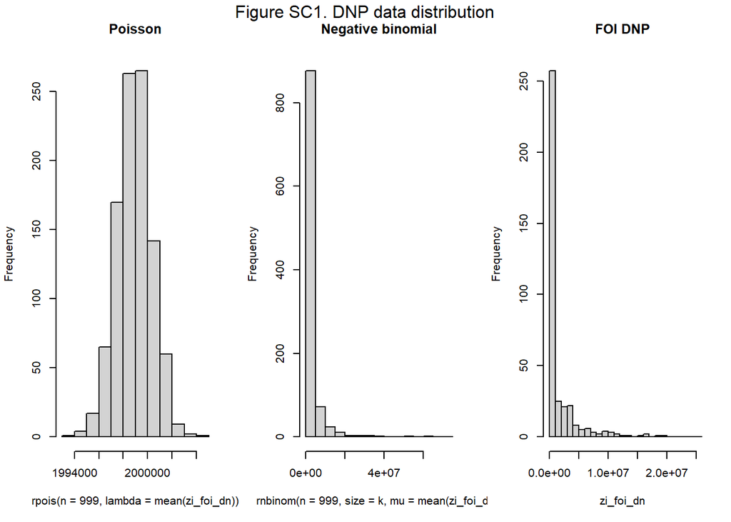

**SSP data distribution**

```
## [1] "Mean/variance= 0.0258122890039858"
## [2] "Variance much higher than the mean -> Overdispersion"
```

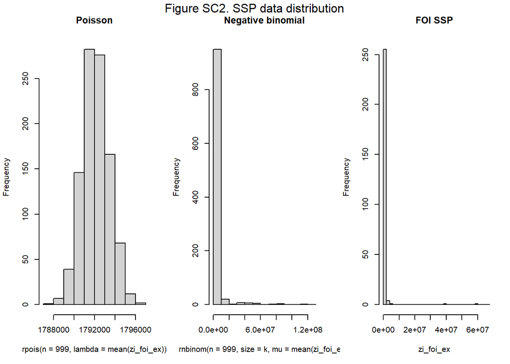

In this case, the negative binomial distribution fits our data much better. Interspecific FOI data, especially when including wild animals, usually follow this distribution since most individuals are expected to have low interaction rates, but some individuals or species will have high interaction rates.

In addition, there were excess of zeros in the data, both in DNP and in SSP, which can be associated with two causes: (i) animals unable two interact, either because there are physical barriers separating them, such as fences; or (ii) because they have different home ranges. The first one can only occur in SSP, while the second may occur in both study areas. Therefore, a zero-inflated negative-binomial distribution could lead to a better fit of the model.

### 6.2. Accounting for spatial overlapping

```r
# Home Range by Kernel
location = c("do", "ex")
for (j in location){
  dat <- get(paste0("dat_",j))
  dat$ID <- gsub('[SUFWSP].*', '', dat$ID)
  dat$X <- NULL

  kernel <- adehabitatHR::kernelUD(as(st_as_sf(dat,
                                               coords = c("xcoord","ycoord"),
                                               crs = "EPSG:25829"),
                                      "Spatial")[,1], grid = 100,
                                   h = "href")
  kernel <- adehabitatHR::getverticeshr(kernel, percent=99, unin = "m",
                                        unout="m", standardize=FALSE)
  kernel <- st_as_sf(kernel)
  op <- st_intersects(kernel, kernel)

  overlap <- data.frame(host1 = character(), host2 = character())

  for (m in 1:length(op)){
    overlap <- rbind(overlap,
                     data.frame(host1 = kernel$id[m],
                                host2 = kernel$id[op[[m]]]))
  }
  overlap$hosts <- paste0(overlap$host1, "_from_", overlap$host2)
  assign(paste0("overlap_", j), overlap)
}
rm(dat,op,kernel,overlap, location, j,m)

# keep only overlapping pairs
foi_do_2h <- foi_do_2h[foi_do_2h$hosts %in% overlap_do$hosts,]
foi_ex_10 <- foi_ex_10[foi_ex_10$hosts %in% overlap_ex$hosts,]

# We also exclude Cattle-Cattle and Pig-Pig interactions in Extremadura (SSP)
foi_ex_10 <- foi_ex_10[foi_ex_10$interaction != "Cow_from_Cow" &
                         foi_ex_10$interaction != "Pig_from_Pig",]

# Merging databases
foi <- do.call("rbind", list(foi_do_2h, foi_ex_10))
rm(list=setdiff(ls(), "foi"))
```

### 6.3. Bayesian modeling

To compare the risk of transmission among species pairs, we use the *brms* package (Bürkner, 2018) for modeling the FOI as response variable ans the pair of interacting species as predictor.

**Required changes:**

- The family and other modeling parameters, such as the number of chains and iterations, control parameters, etc., can be adjusted based on the data. Reducing the number of chains, iterations, acceptance probability (adap_delta), and treedepth can result in faster computations but may also make it more challenging for the model to converge. See `help("brm")` for further details.

```r
# Negative binomial
m_dn <- brm(rel_foi_int ~ 0 + interaction,
            data = foi[which(foi$loc == "doñana" & foi$tint == "2h"),],
            family = negbinomial(), chains = 4, iter = 8000,
            warmup = 3000, control = list(adapt_delta = 0.95,
                                          max_treedepth = 14))
summary(m_dn)
plot(m_dn)
plot(loo(m_dn, moment_match = TRUE))
```

We suggest to take a look at the model plot and at the LOO plot, since they provide valuable information regarding the goodness of fit of the model. The model plot is not shown because it includes a large number of charts.

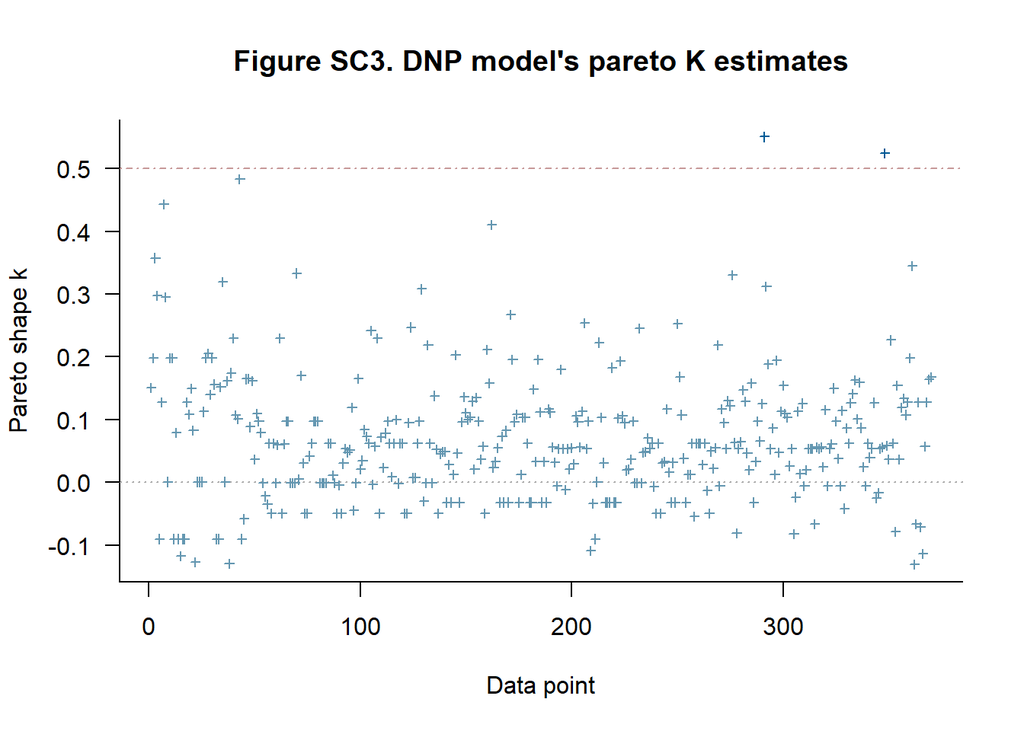

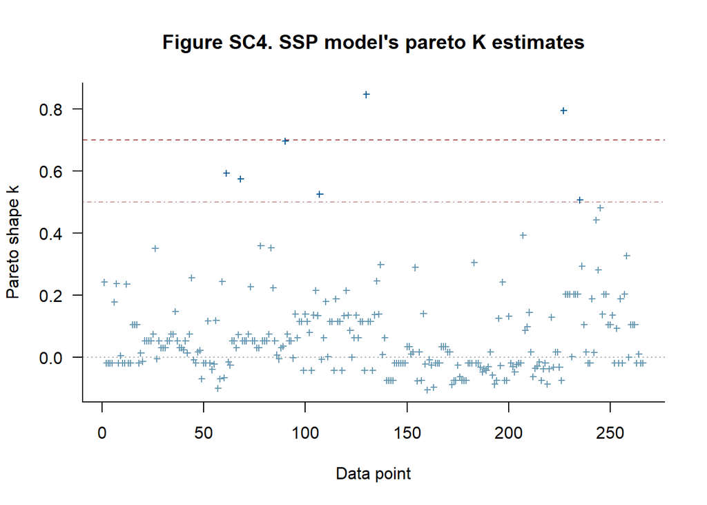

```r
#plot(m)
plot(loo(m), main = "Figure SC3. Model's pareto K estimates")
```

We can see the estimates of the coefficients given for each species pair:

```r
# summary(m)
lazerhawk::brms_SummaryTable(m) %>%
  mutate(Covariate = str_replace_all(Covariate, "interaction", "")) %>%
  mutate(Covariate = str_replace_all(Covariate, "_", " ")) %>%
  knitr::kable(., caption = "Table SC6. Model summary", escape = FALSE) %>%
  kableExtra::kable_styling(full_width = FALSE)
```

Table SC6. DNP model summary

| Covariate | Estimate | Est.Error | l-95% CI | u-95% CI |
| --- | --- | --- | --- | --- |
| Cattle from Cattle | 15.95 | 0.75 | 14.73 | 17.67 |
| Cattle from Fallowdeer | 14.57 | 0.73 | 13.37 | 16.23 |
| Cattle from Reddeer | 13.27 | 0.70 | 12.12 | 14.86 |
| Cattle from Wildboar | 15.61 | 0.89 | 14.19 | 17.65 |
| Fallowdeer from Cattle | 14.35 | 0.73 | 13.15 | 15.99 |
| Fallowdeer from Fallowdeer | 15.79 | 1.21 | 14.01 | 18.75 |
| Fallowdeer from Reddeer | 13.66 | 0.90 | 12.26 | 15.78 |
| Fallowdeer from Wildboar | 15.12 | 1.13 | 13.42 | 17.81 |
| Reddeer from Cattle | 13.13 | 0.68 | 12.00 | 14.65 |
| Reddeer from Fallowdeer | 13.93 | 0.91 | 12.52 | 16.06 |
| Reddeer from Reddeer | 15.14 | 1.09 | 13.47 | 17.65 |
| Reddeer from Wildboar | 15.50 | 1.35 | 13.53 | 18.82 |
| Wildboar from Cattle | 13.91 | 0.86 | 12.52 | 15.91 |
| Wildboar from Fallowdeer | 13.85 | 1.14 | 12.13 | 16.59 |
| Wildboar from Reddeer | 13.82 | 1.37 | 11.84 | 17.09 |
| Wildboar from Wildboar | 15.68 | 1.67 | 13.36 | 19.86 |

Table SC7. SSP model summary

| Covariate | Estimate | Est.Error | l-95% CI | u-95% CI |
| --- | --- | --- | --- | --- |
| Cattle from Pig | 11.01 | 1.68 | 8.70 | 15.19 |
| Cattle from Reddeer | 13.56 | 1.47 | 11.48 | 17.14 |
| Cattle from Wildboar | 9.44 | 1.99 | 6.78 | 14.40 |
| Pig from Cattle | 9.47 | 1.68 | 7.14 | 13.71 |
| Pig from Reddeer | 11.08 | 1.03 | 9.51 | 13.48 |
| Pig from Wildboar | 11.47 | 2.17 | 8.63 | 17.00 |
| Reddeer from Cattle | 13.33 | 1.44 | 11.28 | 16.87 |
| Reddeer from Pig | 11.85 | 1.02 | 10.26 | 14.27 |
| Reddeer from Reddeer | 13.36 | 1.02 | 11.80 | 15.77 |
| Reddeer from Wildboar | 13.15 | 1.04 | 11.54 | 15.63 |
| Wildboar from Cattle | 6.44 | 2.04 | 3.76 | 11.62 |
| Wildboar from Pig | 10.46 | 2.15 | 7.66 | 15.83 |
| Wildboar from Reddeer | 11.62 | 1.05 | 10.02 | 14.12 |
| Wildboar from Wildboar | 19.57 | 2.86 | 16.09 | 26.90 |

### 6.4. Plotting

The differences in the estimated coefficients for each pair of individuals were plotted by means of a ridge plot employing the ggridges package.

**Required changes:**

- Line 184: Modify in case more or less than 4 species are included.
- Lines 185-186: Modify according to the values.

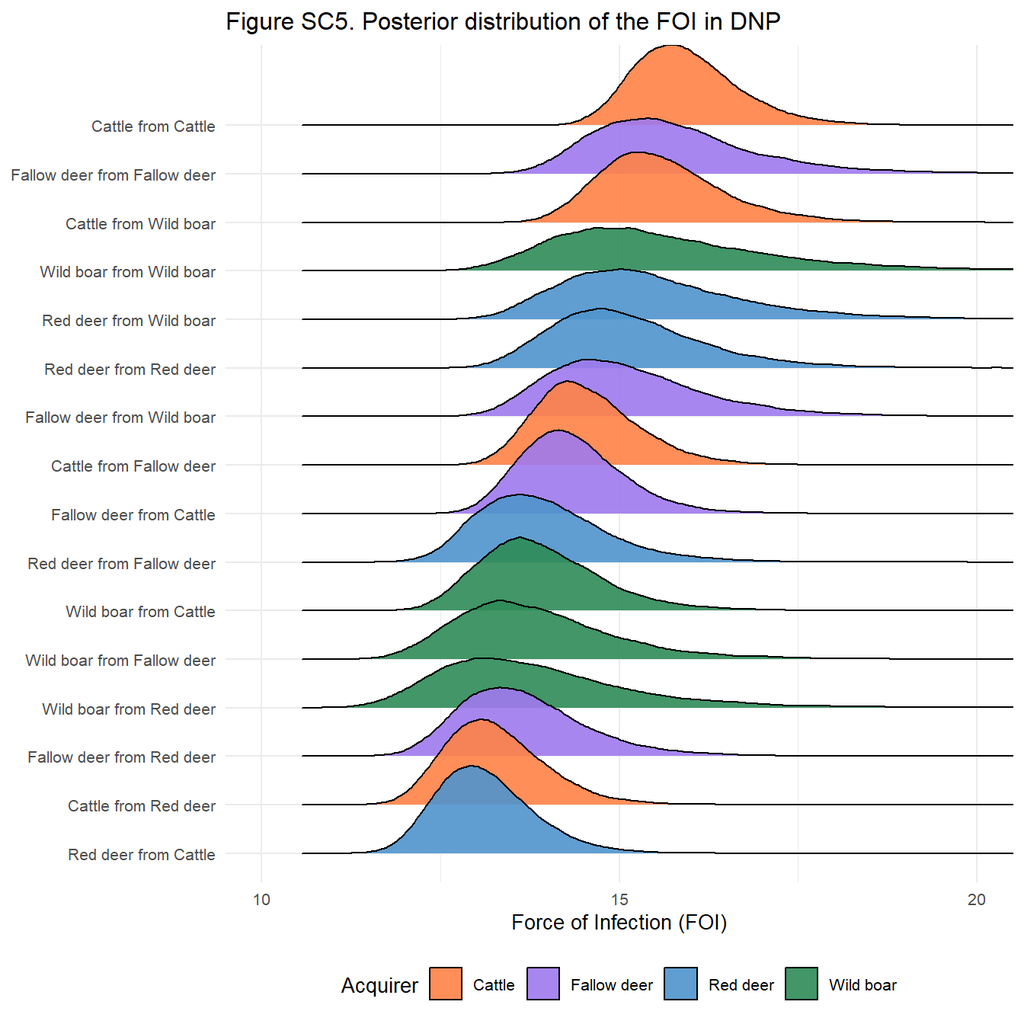

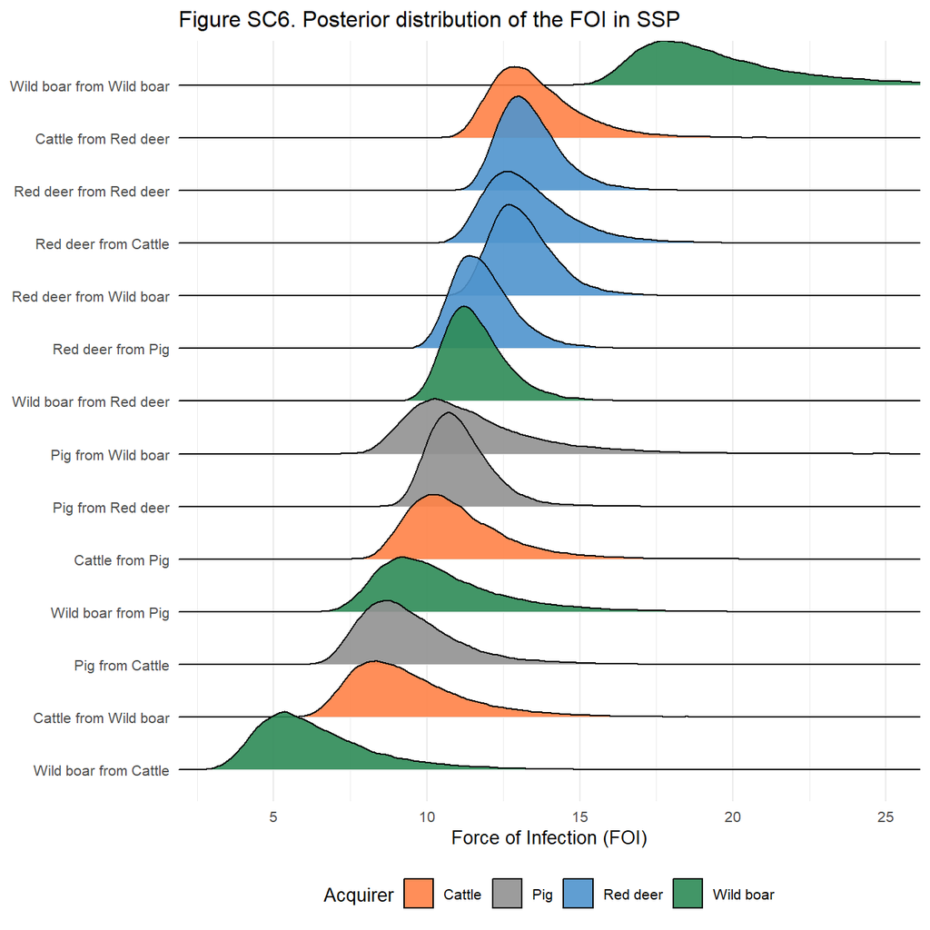

```r
# Empty dataframe
plot_df <- data.frame(Interaction = character(),
                      Values = numeric())

# Get the posterior distributions
for(i in get_variables(m_dn)[1:16]){
  plot_df <- gather_draws(m_dn, !!sym(i))[,4:5] %>%
    rename(Interaction = .variable, Values = .value) %>%
    bind_rows(dn_post)

}
plot_df$Acquirer <- sub("\\ from.*", "", plot_df$Interaction)

# Plot
ggplot(plot_df,mapping = aes(x = Values, y = fct_reorder(Interaction, Values),
                             fill = Acquirer)) +
  geom_density_ridges(alpha = 0.9) +
  scale_fill_manual(values = c("sienna1", "mediumpurple2","steelblue3","seagreen"))+
  theme_minimal() + coord_cartesian(xlim = c(10,20)) +
  scale_x_continuous(breaks = c(10,15,20)) +
  ggtitle("Figure SC5. Posterior distribution of the FOI") +
  xlab("Force of Infection (FOI)") + ylab(NULL) + theme(legend.position="bottom",
                                                        text = element_text(
                                                          size = 10))
```

In this case, values from different areas can be compared graphically to assess the differences in the species involved in disease dynamics. However, the results cannot be compared numerically because of the spatial resolution of the GPS, which was used as the spatial range for transmission in the relative risk of transmission modeling. MoveSTIR considers $λ$ as the amount of pathogen deposited per unit of time in the spatial range, that is, the larger the spatial range considered, the lower the amount of pathogen per surface area, and consequently, the lower the exposure of the acquirers. This does not affect the relative estimations obtained when employing the same spatial range for transmission, but it does have an effect when using different spatial ranges.

## 7. Accounting for location fix interval

The code shown in this appendix is not intended for being reproduced with other telemetry data, so mandatory changes are not indicated. Nonetheless, the code can be run with other data if modified properly.

### 7.1. FOI estimates accuracy

To investigate the effect of the interval at which GPS records locations, we followed these steps:

1. First, we subsampled the SSP trajectories (see Appendix 1) at fix intervals of 10, 15, 20, 30, 45, 60, 90, 120, 180, 360, and 720 minutes.
2. Next, we modeled the relative risk among individuals using moveSTIR (see Appendix 3; Wilber *et al.*, 2022)..
3. We loaded the trajectories using the loop described in Appendix 5, with the values `location = "extremadura"` and `tint = paste0(c(10, 15, 20, 30, 45, 60, 90, 120, 180, 360, 720), "min")`, and combined them into a single object called `foi_tint`.
4. We modeled the FOI in each fix interval subsample following a negative-binomial distribution, with the pair of interacting species as the predictor.

```r
# Converting response variable in integer and time to numeric
foi_tint$rel_foi_int <- as.integer(foi_tint$rel_foi*10^10)
foi_tint$interaction <- as.factor(foi_tint$interaction)
foi_tint$tint_min <- as.numeric(gsub("min", "", foi_tint$tint))

# Cleaning the environment
rm(list=setdiff(ls(), c("foi_tint", "dat_ex")))

# Negative binomial modeling for each sampling interval
tint_list <- list()
for (i in unique(foi_tint$tint_min)){
  f <- foi_tint[foi_tint$tint_min == i,] %>%
    group_by(interaction) %>%
    summarise_at(vars(rel_foi_int), list(rel_foi_int = mean))
  f2 <- f[f$rel_foi_int != 0,]$interaction
  brm_fit <- brm(rel_foi_int ~ 0 + interaction,
                 data = foi_tint[foi_tint$tint_min == i &
                                   foi_tint$interaction %in% f2,],
                 family = negbinomial(), chains = 4, iter = 12000,
                 warmup = 5000, control = list(adapt_delta = 0.95,
                                               max_treedepth = 14))
  a <- data.frame(fixef(brm_fit)) # Storing Estimates and confidence intervals
  a$interaction <- gsub("interaction", "", row.names(a))
  f3 <- data.frame(interaction = f[f$rel_foi_int == 0,]$interaction)
  a <- merge(a, f3, all = T)
  a[is.na(a)] <- 0
  a$tint <- i
  nlist <- paste0("tint_", i)
  tint_list[[nlist]] <- a
}

tint <- Reduce(rbind, tint_list)
tint$interaction <- gsub(" ", "", tint$interaction)
```

The ´tint´ object now includes the estimated coefficients for each species pair in each of the time intervals considered.

5. We divided these estimates by the estimate obtained from the 10-minute time interval data to obtain the proportional accuracy of each time interval relative to the highest resolution time interval. Therefore, the proportional accuracy for a time interval of $t$ minutes was calculated as follows::

$$Proportional\text{ }accuracy_t = estimate_t/estimate_{10}$$

```r
tint <- tint[order(tint$tint),]%>%
  group_by(interaction) %>%
  mutate(relative_est = Estimate/first(Estimate))
tint[is.na(tint)] <- 0
```

6. We categorized the results into three groups based on the interaction rates between species pairs, based on the approach of Triguero-Ocaña *et al.* (2021): (i) High interaction rate pairs, which included intraspecific pairs and red deer-cattle pairs, (ii) Moderate interaction rate pairs, which included red deer-pig and red deer-wild boar pairs, and (iii) Low interaction rate pairs, which comprised the remaining pairs of species.

```r
tint$risk_group <- ifelse(tint$interaction == "Cow_from_Cow" |
                             tint$interaction == "Pig_from_Pig" |
                             tint$interaction == "Reddeer_from_Reddeer" |
                             tint$interaction == "Wildboar_from_Wildboar" |
                             tint$interaction == "Cow_from_Reddeer" |
                             tint$interaction == "Reddeer_from_Cow",
                           "High interaction rate pairs",
                           ifelse(tint$interaction == "Wildboar_from_Reddeer" |
                                    tint$interaction == "Reddeer_from_Wildboar"|
                                    tint$interaction == "Pig_from_Reddeer" |
                                    tint$interaction == "Reddeer_from_Pig",
                                  "Moderate interaction rate pairs",
                                  "Low interaction rate pairs"))
```

8. Finally, we fitted a Generalized Additive Model with cubic splines (Wood 2017) to the proportional accuracy, using the sampling interval as a predictor, to investigate its impact on the accuracy of estimating the FOI..

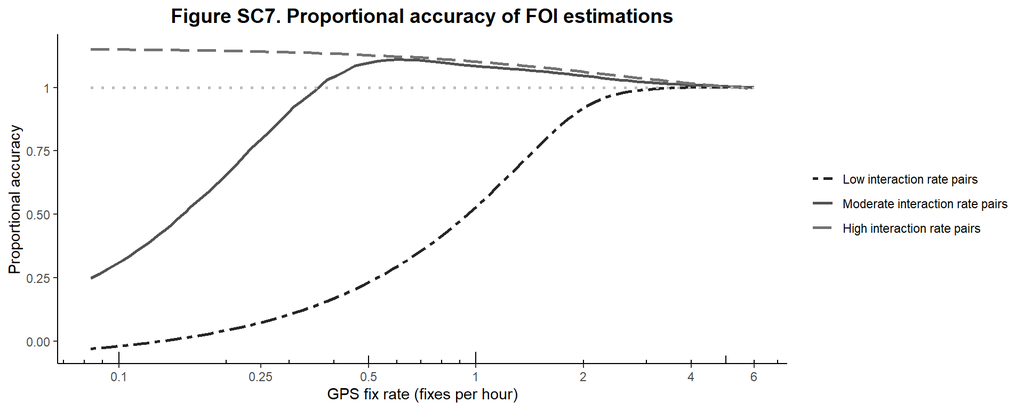

```r
tint$risk_group <- ordered(tint$risk_group,
                            levels = c("Low interaction rate pairs",
                                       "Moderate interaction rate pairs",
                                       "High interaction rate pairs"))
ggplot(data=tint, aes(x=tinvers, y=relative_est_corr,
                      color = risk_group, linetype = risk_group)) +
  scale_x_continuous(breaks=c(0.1, 0.25, 0.5, 1, 2, 4, 6),
                     labels = c("0.1","0.25", "0.5","1", "2", "4", "6")) +
  scale_y_continuous(breaks=c(0, 0.25, 0.5, 0.75, 1, 1.25),
                     labels = c("0.00","0.25", "0.50", "0.75", "1", "1.25")) +
  theme_classic() +
  labs(x = "GPS fix rate (fixes per hour)", y = "Proportional accuracy") +
  geom_smooth(aes(group = risk_group), method = "gam",
              formula = y ~ s(x, bs = "cs"), se=FALSE, size = 1) +
  coord_trans(x="log10")+
  scale_color_manual(values= c(RColorBrewer::brewer.pal
                               (n = 8, name = "Greys")[8],
                               RColorBrewer::brewer.pal
                               (n = 8, name = "Greys")[7],
                               RColorBrewer::brewer.pal
                               (n = 8, name = "Greys")[6])) +
  scale_linetype_manual(values = c(6, 1, 5)) +
  geom_line(y = 1, linetype = 3,
            col =  RColorBrewer::brewer.pal(n = 8, name = "Greys")[4],
            size = 1) +
  ggtitle("Figure SC7. Proportional accuracy of FOI estimations") +
  theme(legend.title=element_blank(),
        plot.title = element_text(size = 14, face = "bold", hjust = 0.5)) +
  annotation_logticks(base = 10, sides = "b", scaled = FALSE)
```

### 7.2. Exposure pattern in the temporal window

In addition, we computed the relative exposure between each pair of individuals in the temporal window. This refers to the FOI from the depositor to the acquirer at each moment of the temporal window since pathogen deposition divided by the total FOI between the depositor and the acquirer (see Appendix 3) .

By visually exploring the relative exposure between each pair of individuals in the temporal window, we can identify exposure patterns, and the differences in the accuracy among sampling intervals may be disclosed.

```r
location = "extremadura"
tint = paste0(c(10, 15, 20, 30, 45, 60,
                90, 120, 180, 360, 720),
              "min")
filetype = "direct_indirect"                # direct_indirect or total


# Loop for preparing the databases by location and time
for (m in location){                        # for all locations
  for (n in tint){                          # for all sampling intervals
    dat <- read.csv(paste0("C:/Files/IREC/PhD/redes/Datasets_",m,
                           "/gps_loc_movestir_", m, ".csv"))
    host_keys <- unique(dat$ID[dat$SP!="Sheep"],)    # host IDs
    assign(paste0("dat_", substr(m, start = 1, stop = 2)), dat)
    foi_list <- list()                      # Empty list

    # Loop for loading trajectory files
    for (i in host_keys){                   # Host 1
      for (j in host_keys){                 # Host 2
        try({
          a <- read.csv(paste0("C:/Files/IREC/PhD/redes/trans_kernels_", m,
                               "/",n,"/", filetype,"_",
                               i,"_from_",j,".csv"))   # Name of the csv
          names(a) <- c("kernel", "datetime")          # Exposure, date and time
          a$vart <- 1:nrow(a) - 1                   # time step
          a$minutes <- as.numeric(gsub("min", "", n))*
            a$vart                                  # time step in minutes
          a$host1 <- i                              # Host 1
          a$host2 <- j                              # Host 2
          a$datetime <- as_datetime(a$datetime)     # seconds to date and time
          a$h1_species <- dat[dat$ID == i,]$SP[1]   # Host 1 species
          a$h2_species <- dat[dat$ID == j,]$SP[1]   # Host 2 species
          nlist <- paste0("foi_",i,"_",j)           # Name in the list
          foi_list[[nlist]] <- a                    # Add data frame to the list
        }, silent = TRUE)
      }
    }

    try({
      # Compiling all the trajectories in a single dataframe
      foi_contact <- Reduce(rbind, foi_list)

      # Variable with both hosts
      foi_contact$hosts <- paste(foi_contact$host1, "_from_", foi_contact$host2)

      foi_contact$interaction <- paste0(foi_contact$h1_species, "_from_",
                                        foi_contact$h2_species)

      # Storing location and time interval
      foi_contact$loc <- m
      foi_contact$tint <- n
      assign(paste0("dir_ind_", substr(m, start = 1, stop = 2), "_", n),
             foi_contact)
    }, silent = TRUE)
  }
}
```

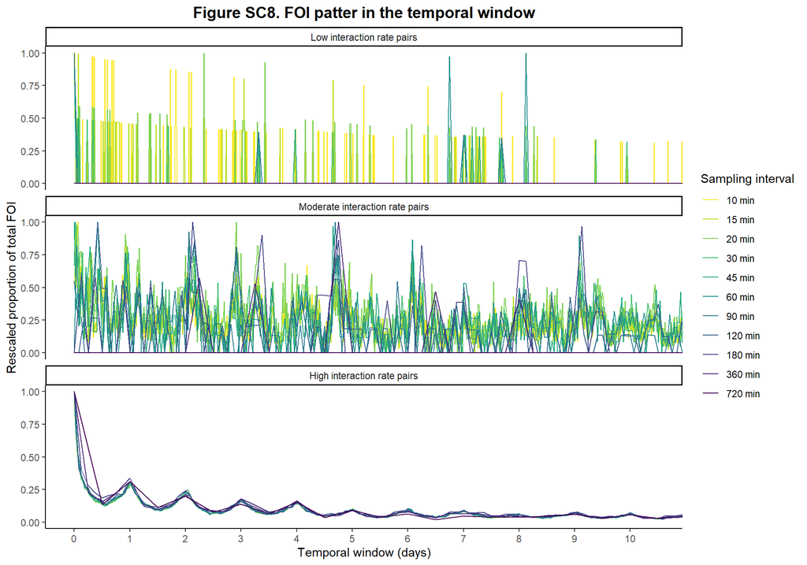

```r
foi_dir_ind <- bind_rows(mget(grep(pattern = "^dir_ind_", x = ls(),
                                   value = TRUE)))
#Assigning risk group
foi_dir_ind$risk_group <-
  ifelse(foi_dir_ind$interaction == "Cow_from_Cow" |
           foi_dir_ind$interaction == "Pig_from_Pig" |
           foi_dir_ind$interaction == "Red deer_from_Red deer" |
           foi_dir_ind$interaction == "Wild boar_from_Wild boar" |
           foi_dir_ind$interaction == "Cow_from_Red deer" |
           foi_dir_ind$interaction == "Red deer_from_Cow",
         "High interaction rate pairs",
         ifelse(foi_dir_ind$interaction == "Wild boar_from_Red deer" |
                  foi_dir_ind$interaction == "Red deer_from_Wild boar" |
                  foi_dir_ind$interaction == "Pig_from_Red deer" |
                  foi_dir_ind$interaction == "Red deer_from_Pig",
                "Moderate interaction rate pairs",
                "Low interaction rate pairs"))

# Mean of the individuals by risk group
foi_dir_ind_corr <- foi_dir_ind %>%
  group_by(minutes, tint, risk_group) %>%
  summarise(kernel_mean = mean(kernel)) %>% group_by(tint, risk_group) %>%
  mutate(kernel_corr = kernel_mean/max(kernel_mean))
foi_dir_ind_corr[is.na(foi_dir_ind_corr)] <- 0
foi_dir_ind_corr$tint <- ordered(foi_dir_ind_corr$tint ,
                                 levels = paste0(c(10, 15, 20, 30, 45, 60,
                                                   90, 120, 180, 360, 720),
                                                 "min"))
foi_dir_ind_corr$risk_group <- ordered(foi_dir_ind_corr$risk_group,
                                       levels =
                                         c("Low interaction rate pairs",
                                           "Moderate interaction rate pairs",
                                           "High interaction rate pairs"))

# Plotting
ggplot(foi_dir_ind_corr,
       aes(x = minutes, y = kernel_corr, color = tint)) +
  theme_classic() +
  labs(colour = "Sampling interval") +
  scale_x_continuous(name = "Temporal window (days)",
                     breaks=seq(0, max(foi_dir_ind_corr$minutes), 24*60),
                     labels = as.character(seq(0, max(foi_dir_ind_corr$minutes),
                                               24*60)/(60*24))) +
  ylab("Rescaled proportion of total FOI") +
  geom_line() +
  coord_cartesian(xlim = c(0, 10*25*60)) + facet_wrap(~risk_group, ncol = 1) +
  ggtitle("Figure SC8. FOI patter in the temporal window") +
  theme(plot.title = element_text(size = 14, face = "bold", hjust = 0.5)) +
  scale_color_viridis(labels = gsub("([c(0,5)])([min])", "\\1 \\2",
                                   levels(foi_dir_ind_corr$tint)),
                     discrete = TRUE, direction = -1)
```

## 8. Spatial representation of the FOI

### 8.1. Extracting spatial FOI

We created and R function called `spatial_risk` which calculates the FOI in each pixel according to 5 arguments:

- `foi`: A dataframe with columns `foi`, with FOI values and `t` indicating date and time.
- `traj`: A dataframe with columns `time`indicating date and time, and `x`and `y`indicating the coordinates.
- `res`: The resolution of the output raster in `crs`units.
- `method`: “cumulative” or “average”, for calculating the sum or the mean of the FOI in each pixel
- `crs`: indicating the Coordinate Reference System in which `x`and `y` are provided in `traj`object.

The function returns a raster with `res`resolution and `crs` Coordinate Reference System.

```r
spatial_risk <- function(foi, traj, res, method, crs){
  # Assign coordinates and transform into spatial object
  foi_coord = merge(foi, traj, all.x =TRUE)
  foi_vect = vect(foi_coord, geom=c("x", "y"), crs=crs)

  # Raster to plot the values
  r_template = terra::rast(xmin = min(traj$x), xmax = max(traj$x),
                           ymin = min(traj$y), ymax = max(traj$y),
                           crs = crs,
                           resolution = res)

  # Rasterize foi values
  spatial_foi = rasterize(foi_vect, r_template, field = "foi",
                           fun = ifelse(method == "cumulative", sum,
                                        ifelse(method == "average", mean,
                                               print("Error: Method must be
                                                     cumulative or average"))),
                           na.rm = TRUE)
  return(spatial_foi)
}

# Then we ran the function for all the wildlife-livestock pairs and save the
# raster file.

library(tidyverse)
library(sf)

# Defining deposition and acquisition rates
location = c("doñana", "extremadura")       # locations
tint = c("2h", "10min")                     # sampling intervals
filetype = "total"                          # direct_indirect or total

# Loop for preparing the databases by location and time
for (m in location){                        # for all locations
  for (n in tint){                          # for all sampling intervals
    dat <- read.csv(paste0("C:/Files/IREC/PhD/redes/Datasets_",m,
                           "/gps_loc_movestir_", m, ".csv"))
    host_keys <- unique(dat$ID[dat$SP!="Sheep"],)    # host IDs
    assign(paste0("dat_", substr(m, start = 1, stop = 2)), dat)
    foi_list <- list()
    ctmm_list <- list()

    # Loop for loading trajectory files
    for (i in host_keys){                   # Host 1
      for (j in host_keys){                 # Host 2
        try({
          a <- read.csv(paste0("C:/Files/IREC/PhD/redes/trans_kernels_", m,
                               "/",n,"/", filetype,"_",
                               i,"_from_",j,".csv"))   # Name of the csv
          names(a) <- c("kernel", "time")           # Exposure and time
          a$host1 <- i                              # Host 1
          a$host2 <- j                              # Host 2
          a$h1_species <- dat[dat$ID == i,]$SP[1]   # Host 1 species
          a$h2_species <- dat[dat$ID == j,]$SP[1]   # Host 2 species
          nlist <- paste0("foi_",i,"_",j)           # Name in the list
          foi_list[[nlist]] <- a                    # Add data frame to the list

        }, silent = TRUE)
      }

      # Loading CTMM data of host 1
      ctmm_data <- read.csv(paste0("C:/Files/IREC/PhD/redes/Datasets_",m,
                                   "/ctmm_data_", n, "/traj_", i, ".csv"))
      ctmm_data$host1 <- sub("(\\d)[^0-9].*", "\\1", i)
      ctmm_data$id <- NULL
      ctmm_data$time <- ctmm_data$time_s; ctmm_data$time_s <- NULL
      ctmm_name <- paste0("ctmm_", i)
      ctmm_list[[ctmm_name]] <- ctmm_data
    }

    try({
      # Compiling all the trajectories in a single dataframe
      foi_contact <- Reduce(rbind, foi_list)

      # Including excretion and acquisition
      foi_contact$lambda <- as.numeric(ifelse(foi_contact$h2_species ==
                                                "Wild boar" |
                                                foi_contact$h2_species == "Pig",
                                              0.8, ifelse(
                                                foi_contact$h2_species == "Cow",
                                                0.35, ifelse(
                                                  foi_contact$h2_species ==
                                                    "Red deer" |
                                                    foi_contact$h2_species ==
                                                    "Fallow deer",
                                                  0.43, "ERROR"))))

      foi_contact$beta <- as.numeric(ifelse(foi_contact$h1_species ==
                                              "Wild boar" |
                                              foi_contact$h1_species == "Pig",
                                            0.18, ifelse(
                                              foi_contact$h1_species == "Cow",
                                              0.36, ifelse(
                                                foi_contact$h1_species ==
                                                  "Red deer"|
                                                  foi_contact$h1_species ==
                                                  "Fallow deer",
                                                0.36, "ERROR"))))

      # From kernel of trajectories to relative risk of transmission by acquisition
      # and deposition rates
      foi_contact$foi <- foi_contact$kernel * foi_contact$beta *
        foi_contact$lambda

      # Adding "Wildlife" and "Livestock" labels
      foi_contact$host2_group <- ifelse(foi_contact$h2_species == "Cow" |
                                          foi_contact$h2_species == "Pig",
                                        "Livestock", "Wildlife")

      foi_contact$host1_group <- ifelse(foi_contact$h1_species == "Cow" |
                                          foi_contact$h1_species == "Pig",
                                        "Livestock", "Wildlife")

      # We create a list in which every object is named as host1 ID, and
      # "foi" values
      # are the FOI experienced by the given host1 from all other hosts
      # (distinguishing between wildlife and livestock) at the moment indicated
      # by "time" value.
      foi_contact$host1 <- sub("(\\d)[^0-9].*", "\\1", foi_contact$host1)
      foi_spatial <- foi_contact[,c("host1", "host1_group", "host2_group", "foi",
                                    "time")] %>%
        group_by(host1, host1_group, host2_group, time) %>%
        summarize(foi = sum(foi, na.rm = TRUE))

      list_loc <- split(foi_spatial , f = foi_spatial$host1)
      assign(paste0("fois_time_", m), list_loc)

      # We create a dataframe with all the CTMM trajectories
      all_traj <- Reduce(rbind, ctmm_list)
      assign(paste0("ctmm_traj_", m), all_traj)

      # Delete unnecessary objects
      rm(list = c("foi_contact", "foi_spatial", "list_loc", "foi_list",
                  "ctmm_data", "dat", "all_traj", "a", "ctmm_list"))
    }, silent = TRUE)
  }
}


for (j in location) {
  list_spatial <- list()      # Empty list
  for (i in names(get(paste0("fois_time_", j)))){
    fois_spatial <- get(paste0("fois_time_", j))[[i]]

    # Keeping the wildlife FOI from livestock and livestock FOI from wildlife
    # Other values are not considered
    if (fois_spatial[1,]$host1_group == "Livestock") {
      fois_spatial <- fois_spatial[fois_spatial$host2_group == "Wildlife",]
    }
    if (fois_spatial[1,]$host1_group == "Wildlife") {
      fois_spatial <- fois_spatial[fois_spatial$host2_group == "Livestock",]
    }

    # Applying the function
    fois_spatial_rast <- spatial_risk(foi = fois_spatial,
                                 traj = get(paste0("ctmm_traj_", j)),
                                 res = 50,
                                 method = "cumulative",
                                 crs = "EPSG:25829")

    # Saving in a list
    nlist <- paste0(i, "_", fois_spatial$host1_group[[1]])
    list_spatial[[nlist]] <- fois_spatial_rast
  }

  # Sum rasters and compute the proportion
  list_spatial <- terra::app(terra::rast(list_spatial), sum, na.rm = TRUE)

  list_spatial <- 100*list_spatial/terra::global(list_spatial,
                                                 fun = "sum",
                                                 na.rm = TRUE)[[1]]

  # Saving the output
  assign(paste0("spat_foi_interface_", j), list_spatial)
    terra::writeRaster(list_spatial, paste0("spat_foi_interface_", j, ".tif"),
                     filetype = "GTiff", overwrite = TRUE)

  rm(list = c("fois_spatial", "fois_spatial_rast", "list_spatial"))
}
```

### 8.2. Home Ranges estimation

For the estimation of the Home Ranges, we used 95% Kernel Density Estimation.

```r
for (j in location){
    kernel <- adehabitatHR::kernelUD(as(st_as_sf(get(paste0("ctmm_traj_", j)),
                                                 coords = c("x","y"),
                                                 crs = "EPSG:25829"),
                                        "Spatial")[,1], grid = 80,
                                     h = "href")
    kernel <- adehabitatHR::getverticeshr(kernel, percent=95, unin = "m",
                                          unout="m", standardize=FALSE)

    # For adding species and "Livestock"/"Wildlife" labels
    kernel <- get(paste0("dat_", substr(j, start = 1, stop = 2)))[,c("ID", "SP"),] %>%
      mutate(ID = sub("(\\d)[^0-9].*", "\\1", ID)) %>%
      mutate(group = case_when(SP == "Cow" ~ "Livestock",
                               SP == "Pig" ~ "Livestock",
                               TRUE ~ "Wildlife")) %>% unique() %>%
      merge(st_as_sf(kernel), ., all.x = TRUE, by.x = "id", by.y = "ID")

    assign(paste0("HR_", j), kernel)

    st_write(kernel, paste0("HR_", j, ".shp"), driver = "ESRI Shapefile",
             delete_dsn = TRUE)

    rm("kernel")
}
```

## 9. Supporting information references

Ballesteros, C., Garrido, J.M., Vicente, J., Romero, B., Galindo, R.C., Minguijon, E. *et al.* (2009). First data on Eurasian wild boar response to oral immunization with BCG and challenge with a Mycobacterium bovis field strain. *Vaccine*, 27, 6662-6668.

Bürkner, P.-C. (2017). brms: An R package for Bayesian multilevel models using Stan. *Journal of statistical software*, 80, 1-28.

Calabrese, J.M., Fleming, C.H., Gurarie, E. & Freckleton, R. (2016). ctmm: an R package for analyzing animal relocation data as a continuous‐time stochastic process. Methods in Ecology and Evolution, 7, 1124-1132.

Carpenter, B., Gelman, A., Hoffman, M.D., Lee, D., Goodrich, B., Betancourt, M. *et al.* (2017). Stan: A probabilistic programming language. *Journal of statistical software*, 76.

Fine, A.E., Bolin, C.A., Gardiner, J.C. & Kaneene, J.B. (2011). A Study of the Persistence of Mycobacterium bovis in the Environment under Natural Weather Conditions in Michigan, USA. *Vet Med Int*, 2011, 765430.

Griffin, J.F., Rodgers, C.R., Liggett, S. & Mackintosh, C.G. (2006). Tuberculosis in ruminants: characteristics of intra-tonsilar Mycobacterium bovis infection models in cattle and deer. *Tuberculosis (Edinb)*, 86, 404-418.

Jackson, R., de Lisle, G.W. & Morris, R.S. (1995). A study of the environmental survival of Mycobacterium bovis on a farm in New Zealand. *N Z Vet J*, 43, 346-352.

McCorry, T., Whelan, A.O., Welsh, M.D., McNair, J., Walton, E., Bryson, D.G. *et al.* (2005). Shedding of Mycobacterium bovis in the nasal mucus of cattle infected experimentally with tuberculosis by the intranasal and intratracheal routes. *Vet Rec*, 157, 613-618.

Neill, S.D., Bryson, D.G. & Pollock, J.M. (2001). Pathogenesis of tuberculosis in cattle. *Tuberculosis (Edinb)*, 81, 79-86.

Santos, N., Almeida, V., Gortazar, C. & Correia-Neves, M. (2015). Patterns of Mycobacterium tuberculosis-complex excretion and characterization of super-shedders in naturally-infected wild boar and red deer. *Vet Res*, 46, 129.

Triguero-Ocaña, R., Laguna, E., Jimenez-Ruiz, S., Fernandez-Lopez, J., Garcia-Bocanegra, I., Barasona, J.A. *et al.* (2021). The wildlife-livestock interface on extensive free-ranging pig farms in central Spain during the “montanera” period. *Transbound Emerg Dis*, 68, 2066-2078.

Wilber, M.Q., Yang, A., Boughton, R., Manlove, K.R., Miller, R.S., Pepin, K.M. *et al.* (2022). A model for leveraging animal movement to understand spatio-temporal disease dynamics. *Ecol Lett*, 25, 1290-1304.

Wood, S. N. (2017). Generalized additive models: an introduction with R. *CRC press*.

Yang, A., Wilber, M.Q., Manlove, K.R., Miller, R.S., Boughton, R., Beasley, J., Northrup, J., VerCauteren, K.C., Wittemyer, G. & Pepin, K. (2023) Deriving spatially explicit direct and indirect interaction networks from animal movement data. *Ecol Evol,* **13,** e9774.